# Anàlisi de l’índex de pobresa temporal Catalunya · 2011

### 4.7.2 3.6.2 Ús del temps segons el tram d’ingressos

Per no saturar els gràfics amb comparacions, s’utilitza el tram d’ingressos agrupat en 5 categories (`TRAM_INGRESSOS_REDUIT`).

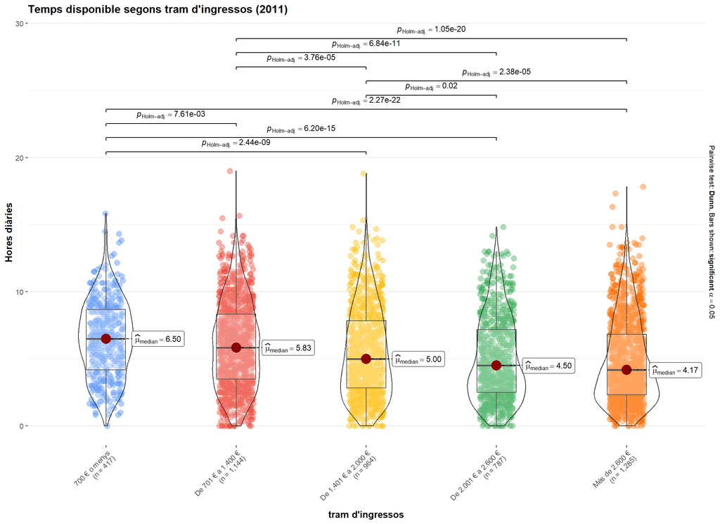

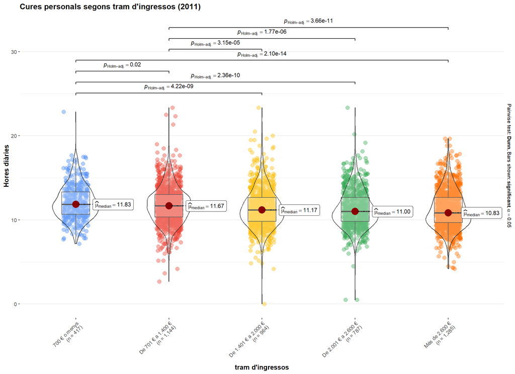

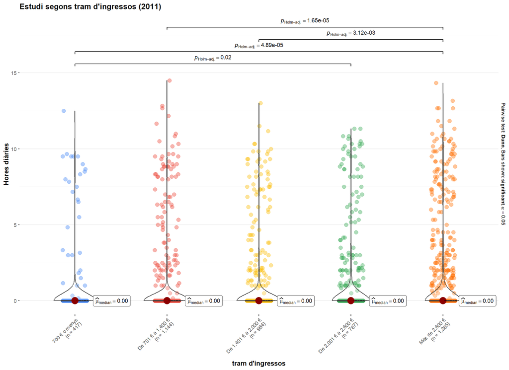

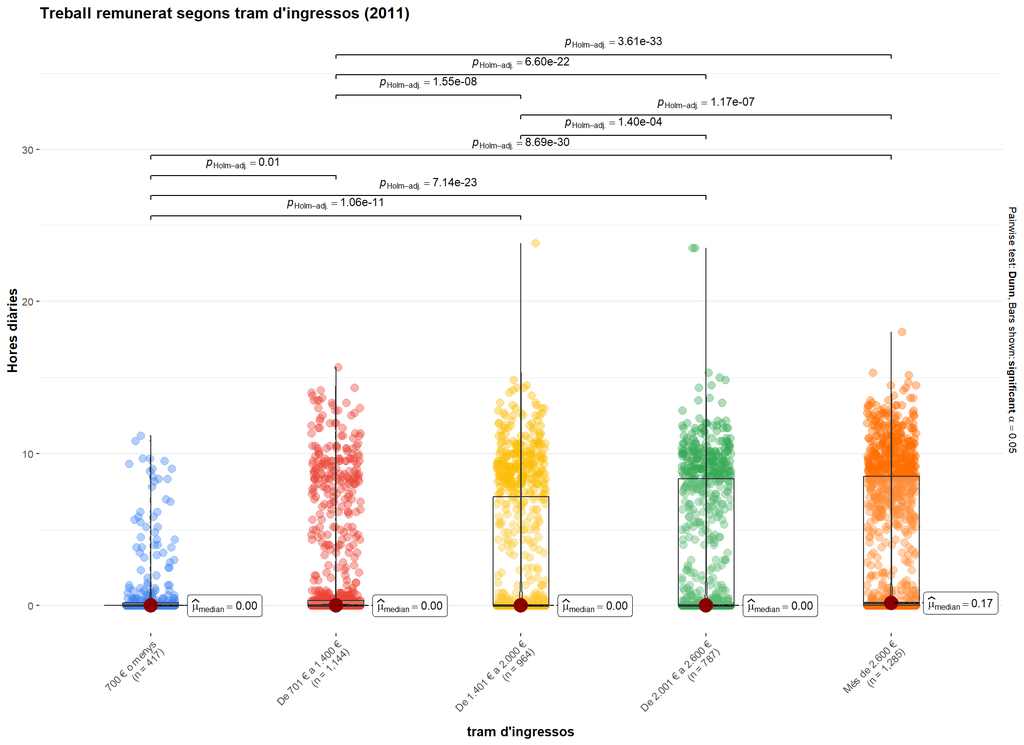

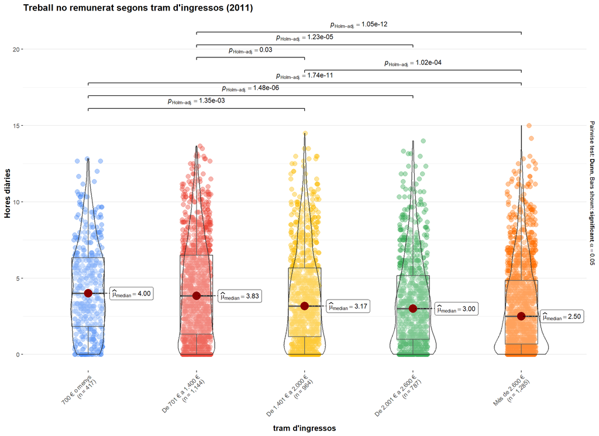

```r
walk(plots_us_temps_grups(dades_long_2011, "TRAM_INGRESSOS_REDUIT", "tram d'ingressos"), print)
```

# 5 4 Modelització

## 5.1 4.1 Interpretació dels models logit

#### 5.1.0.1 1. Fórmula general d’un model logístic

Un model logístic (o logit) amb efectes fixos i aleatoris té la forma:

$$\text{logit}(P(Y=1)) = \log\left(\frac{P(Y=1)}{1-P(Y=1)}\right)
= \beta_0 + \beta_1 X_1 + \beta_2 X_2 + \cdots + u_j$$

on:

- $Y = 1$ és l’esdeveniment (**pobresa temporal**)
- $u_j$ és l’intercept aleatori del grup $j$ (la **llar**)
- els $\beta$ són coeficients en **log-odds**

#### 5.1.0.2 2. Per què s’exponencien els coeficients?

Els coeficients $\beta$ estan en log-odds, que són difícils d’interpretar. Per això es calcula l’*odds ratio*:

$$\text{OR} = e^{\beta}$$

- **OR > 1** → augmenta la probabilitat de pobresa temporal
- **OR < 1** → disminueix la probabilitat de pobresa temporal
- **OR = 1** → cap efecte

#### 5.1.0.3 3. Interpretació segons el tipus de variable

- **Variables numèriques.** Per cada unitat addicional de $X$, les *odds* de pobresa temporal es multipliquen per l’OR. Si $\beta_1 = 0.20$, l’OR és $e^{0.20} = 1.22$: les odds augmenten un **22%**.
- **Variables categòriques.** Cada categoria es compara amb la categoria de referència. Un OR de 1.71 vol dir un 71% més d’odds que la categoria base; un OR de 0.304, un 70% menys d’odds.
- **Variables dicotòmiques.** S’interpreten igual. Si `SEXEHome` té un OR de 0.77, els homes tenen un 23% menys d’odds de pobresa temporal que les dones.
- **Intervals de confiança.** Un OR només és significatiu si l’IC al 95% no inclou l’1. Amb OR = 1.33 i IC95% = [1.05, 1.68] l’efecte és significatiu; amb OR = 0.96 i IC95% = [0.68, 1.36] no hi ha evidència d’efecte.
- **Intercept.** És el logit de la probabilitat de pobresa temporal per al perfil base (totes les variables a la categoria de referència o a 0). Exponenciat, dona les odds del perfil base.
- **Efectes aleatoris (`1 | IDLLAR`).** Cada llar té un intercept propi que recull les diferències no observades entre llars i la correlació entre individus d’una mateixa llar. No s’interpreta com un coeficient, sinó com a variabilitat entre grups no explicada pels predictors.

## 5.2 4.2 Ajust i selecció de models

```r
mod0 <- glm(
  IPT ~ SEXE + TRAM_EDAT + AD_DEP + DEGURBA + TIPUS_LLAR + TIPUS_DIA +
    NAC + ESTAT_CIVIL + ESTUDI_ALT + NUM_MEMBRES + AJ_TOTAL +
    VOL_TOTAL + REL_ACT,
  data = dades_models_2011, family = binomial(link = "logit"))

mod1 <- glmmTMB(
  IPT ~ SEXE + TRAM_EDAT + AD_DEP + DEGURBA + TIPUS_LLAR + TIPUS_DIA +
    NAC + ESTAT_CIVIL + ESTUDI_ALT + NUM_MEMBRES + AJ_TOTAL +
    VOL_TOTAL + REL_ACT + (1 | IDLLAR),
  data = dades_models_2011, family = binomial(link = "logit"))

mod2 <- glmmTMB(
  IPT ~ SEXE + TRAM_EDAT + AD_DEP + DEGURBA + TIPUS_LLAR + TIPUS_DIA +
    NAC + ESTUDI_ALT + AJ_TOTAL + VOL_TOTAL + REL_ACT + (1 | IDLLAR),
  data = dades_models_2011, family = binomial(link = "logit"))

mod3 <- glmmTMB(
  IPT ~ SEXE + TRAM_EDAT + DEGURBA + TIPUS_LLAR + TIPUS_DIA + NAC + ESTUDI_ALT +
    VOL_TOTAL + REL_ACT + (1 | IDLLAR),
  data = dades_models_2011, family = binomial(link = "logit"))

mod4 <- glmmTMB(
  IPT ~ SEXE + TRAM_EDAT + DEGURBA + TIPUS_LLAR + TIPUS_DIA + NAC + ESTUDI_ALT +
    REL_ACT + (1 | IDLLAR),
  data = dades_models_2011, family = binomial(link = "logit"))
```

Els models es comparen amb els criteris AIC i BIC, amb proves de raó de versemblança entre models niats (`mod1` ⊃ `mod2` ⊃ `mod3` ⊃ `mod4`) i amb el criteri teòric de les variables que es volen estudiar, encara que no siguin significatives.

```r
comparacio <- AIC(mod0, mod1, mod2, mod3, mod4) %>%
  rownames_to_column("Model") %>%
  left_join(BIC(mod0, mod1, mod2, mod3, mod4) %>% rownames_to_column("Model") %>% select(Model, BIC),
            by = "Model")

knitr::kable(comparacio, digits = 1, caption = "Comparació de models (AIC i BIC)")
```

Comparació de models (AIC i BIC)

| Model | df | AIC | BIC |
| --- | --- | --- | --- |
| mod0 | 28 | 5363.1 | 5549.1 |
| mod1 | 29 | 5272.5 | 5465.2 |
| mod2 | 25 | 5278.0 | 5444.0 |
| mod3 | 23 | 5276.1 | 5428.9 |
| mod4 | 22 | 5276.9 | 5423.0 |

```r
anova(mod1, mod2, mod3, mod4) %>%
  as.data.frame() %>%
  knitr::kable(digits = 3, caption = "Proves de raó de versemblança entre models niats")
```

Proves de raó de versemblança entre models niats

|  | Df | AIC | BIC | logLik | deviance | Chisq | Chi Df | Pr(>Chisq) |
| --- | --- | --- | --- | --- | --- | --- | --- | --- |
| mod4 | 22 | 5276.891 | 5423.039 | -2616.445 | 5232.891 | NA | NA | NA |
| mod3 | 23 | 5276.071 | 5428.863 | -2615.036 | 5230.071 | 2.819 | 1 | 0.093 |
| mod2 | 25 | 5277.960 | 5444.038 | -2613.980 | 5227.960 | 2.112 | 2 | 0.348 |
| mod1 | 29 | 5272.522 | 5465.172 | -2607.261 | 5214.522 | 13.438 | 4 | 0.009 |

```r
mod_final <- mod4
```

## 5.3 4.3 Model final

### 5.3.1 4.3.1 Efectes fixos

```r
summary(mod_final)
```

```
##  Family: binomial  ( logit )
## Formula:
## IPT ~ SEXE + TRAM_EDAT + DEGURBA + TIPUS_LLAR + TIPUS_DIA + NAC +
##     ESTUDI_ALT + REL_ACT + (1 | IDLLAR)
## Data: dades_models_2011
##
##       AIC       BIC    logLik -2*log(L)  df.resid
##    5276.9    5423.0   -2616.4    5232.9      5649
##
## Random effects:
##
## Conditional model:
##  Groups Name        Variance Std.Dev.
##  IDLLAR (Intercept) 1.434    1.197
## Number of obs: 5671, groups:  IDLLAR, 3048
##
## Conditional model:
##                                   Estimate Std. Error z value Pr(>|z|)
## (Intercept)                      -1.115758   0.257066  -4.340 1.42e-05 ***
## SEXEHome                         -0.529699   0.081245  -6.520 7.04e-11 ***
## TRAM_EDAT25-44                    1.270862   0.225518   5.635 1.75e-08 ***
## TRAM_EDAT45-64                    1.181098   0.229317   5.150 2.60e-07 ***
## TRAM_EDAT65+                      1.074928   0.366869   2.930  0.00339 **
## DEGURBA20.000-100.000 habitants  -0.008015   0.115101  -0.070  0.94448
## DEGURBA+100.000 habitants        -0.200274   0.110758  -1.808  0.07057 .
## TIPUS_LLARUnipersonal            -0.927710   0.187269  -4.954 7.27e-07 ***
## TIPUS_LLARParella sense fills    -0.336385   0.131163  -2.565  0.01033 *
## TIPUS_LLARMonoparental fills <25  0.055131   0.216542   0.255  0.79903
## TIPUS_LLARMonoparental fills ≥25 -0.390116   0.278032  -1.403  0.16058
## TIPUS_LLARParella amb fills ≥25  -0.298925   0.182047  -1.642  0.10059
## TIPUS_LLARAltres                 -0.043477   0.169885  -0.256  0.79801
## TIPUS_DIADia inusual             -1.298113   0.119476 -10.865  < 2e-16 ***
## NACEstrangera                     0.047767   0.156750   0.305  0.76057
## ESTUDI_ALTSecundaria 1a etapa     0.041728   0.135531   0.308  0.75817
## ESTUDI_ALTSecundaria 2a etapa    -0.068155   0.133165  -0.512  0.60879
## ESTUDI_ALTSuperior               -0.240181   0.149456  -1.607  0.10805
## REL_ACTAturat                    -1.963694   0.170948 -11.487  < 2e-16 ***
## REL_ACTJubilat                   -0.514808   0.238103  -2.162  0.03061 *
## REL_ACTInactiu                   -2.608709   0.294029  -8.872  < 2e-16 ***
## ---
## Signif. codes:  0 '***' 0.001 '**' 0.01 '*' 0.05 '.' 0.1 ' ' 1
```

*Odds ratios* i intervals de confiança al 95%:

```r
taula_or <- broom.mixed::tidy(mod_final, effects = "fixed", conf.int = TRUE, exponentiate = TRUE) %>%
  transmute(Variable = term, OR = estimate,
            `IC 95% inf.` = conf.low, `IC 95% sup.` = conf.high, `p-valor` = p.value) %>%
  mutate(across(where(is.numeric), ~ round(.x, 3)))

datatable(taula_or, rownames = FALSE, options = list(pageLength = 15)) %>%
  formatStyle("p-valor", fontWeight = styleInterval(0.05, c("bold", "normal")))
```

| Variable | OR | IC 95% inf. | IC 95% sup. | p-valor |
| --- | --- | --- | --- | --- |
| (Intercept) | 0.328 | 0.198 | 0.542 | 0 |
| SEXEHome | 0.589 | 0.502 | 0.69 | 0 |
| TRAM_EDAT25-44 | 3.564 | 2.291 | 5.545 | 0 |
| TRAM_EDAT45-64 | 3.258 | 2.078 | 5.107 | 0 |
| TRAM_EDAT65+ | 2.93 | 1.427 | 6.013 | 0.003 |
| DEGURBA20.000-100.000 habitants | 0.992 | 0.792 | 1.243 | 0.944 |
| DEGURBA+100.000 habitants | 0.819 | 0.659 | 1.017 | 0.071 |
| TIPUS_LLARUnipersonal | 0.395 | 0.274 | 0.571 | 0 |
| TIPUS_LLARParella sense fills | 0.714 | 0.552 | 0.924 | 0.01 |
| TIPUS_LLARMonoparental fills &lt;25 | 1.057 | 0.691 | 1.615 | 0.799 |

[output cut: 11 more lines]

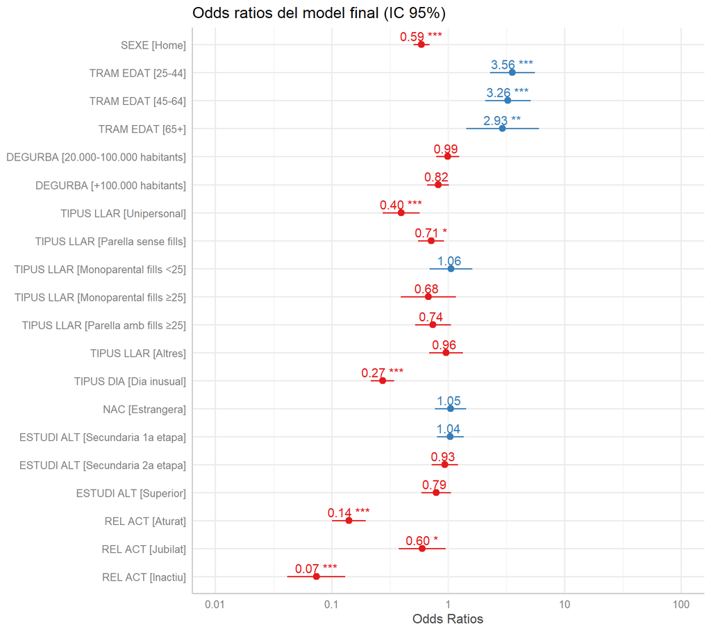

```r
plot_model(mod_final, transform = "exp", show.values = TRUE, value.offset = 0.3,
           title = "Odds ratios del model final (IC 95%)") +
  theme_sjplot()
```

### 5.3.2 4.3.2 Efectes aleatoris

```r
VarCorr(mod_final)
```

```
##
## Conditional model:
##  Groups Name        Std.Dev.
##  IDLLAR (Intercept) 1.1974
```

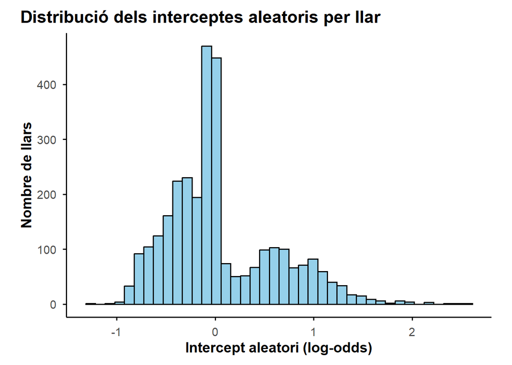

```r
sigma_re <- unname(attr(VarCorr(mod_final)$cond$IDLLAR, "stddev"))

ranef(mod_final)$cond$IDLLAR %>%
  as.data.frame() %>%
  ggplot(aes(x = `(Intercept)`)) +
  geom_histogram(bins = 40, fill = "#95D0EA", color = "black") +
  labs(title = "Distribució dels interceptes aleatoris per llar",
       x = "Intercept aleatori (log-odds)", y = "Nombre de llars") +
  tema_tfg()
```

La desviació estàndard de l’intercept aleatori és de σ = 1.197.

```r
icc_mod <- performance::icc(mod_final)
r2_mod <- performance::r2(mod_final)

tibble(
  Mesura = c("ICC ajustat", "ICC no ajustat", "R² marginal (Nakagawa)", "R² condicional (Nakagawa)"),
  Valor = round(c(icc_mod$ICC_adjusted, icc_mod$ICC_unadjusted,
                  unname(r2_mod$R2_marginal), unname(r2_mod$R2_conditional)), 3)
) %>%
  knitr::kable(caption = "Variabilitat entre llars i capacitat explicativa")
```

Variabilitat entre llars i capacitat explicativa

| Mesura | Valor |
| --- | --- |
| ICC ajustat | 0.304 |
| ICC no ajustat | 0.220 |
| R² marginal (Nakagawa) | 0.276 |
| R² condicional (Nakagawa) | 0.496 |

L’ICC no ajustat respon a quanta variació hi ha entre grups en general; l’ICC ajustat, a quanta en queda un cop explicada la part atribuïble a les covariables. Amb un ICC ajustat de 0.304, aproximadament el 30.4% de la variabilitat latent és atribuïble a diferències entre llars. L’R² marginal (0.276) indica la part explicada pels efectes fixos, i el condicional (0.496) la part explicada per fixos i aleatoris conjuntament.

### 5.3.3 4.3.3 Validació del model

```r
res_sim <- simulateResiduals(mod_final)
proves_res <- testResiduals(res_sim, plot = FALSE)

tibble(
  Test = c("Uniformitat (Kolmogorov-Smirnov)", "Dispersió", "Outliers"),
  `p-valor` = round(c(proves_res$uniformity$p.value,
                      proves_res$dispersion$p.value,
                      proves_res$outliers$p.value), 3)
) %>%
  knitr::kable(caption = "Tests sobre els residus simulats (DHARMa)")
```

Tests sobre els residus simulats (DHARMa)

| Test | p-valor |
| --- | --- |
| Uniformitat (Kolmogorov-Smirnov) | 0.001 |
| Dispersió | 0.000 |
| Outliers | 0.262 |

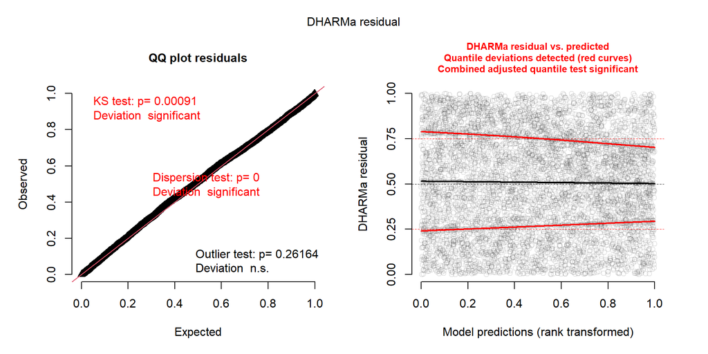

```r
plot(res_sim)
```

```r
check_collinearity(mod_final) %>%
  as.data.frame() %>%
  knitr::kable(digits = 2, caption = "Multicol·linealitat (VIF)")
```

Multicol·linealitat (VIF)

| Term | VIF | VIF_CI_low | VIF_CI_high | SE_factor | Tolerance | Tolerance_CI_low | Tolerance_CI_high |
| --- | --- | --- | --- | --- | --- | --- | --- |
| SEXE | 1.05 | 1.04 | 1.06 | 1.02 | 0.95 | 0.94 | 0.97 |
| TRAM_EDAT | 10.92 | 10.49 | 11.29 | 1.49 | 0.09 | 0.09 | 0.10 |
| DEGURBA | 1.04 | 1.03 | 1.05 | 1.01 | 0.96 | 0.96 | 0.97 |
| TIPUS_LLAR | 1.23 | 1.21 | 1.26 | 1.02 | 0.81 | 0.79 | 0.83 |
| TIPUS_DIA | 1.06 | 1.05 | 1.07 | 1.03 | 0.94 | 0.93 | 0.96 |
| NAC | 1.07 | 1.06 | 1.08 | 1.04 | 0.93 | 0.92 | 0.95 |
| ESTUDI_ALT | 1.34 | 1.31 | 1.37 | 1.05 | 0.75 | 0.73 | 0.77 |
| REL_ACT | 10.95 | 10.52 | 11.32 | 1.49 | 0.09 | 0.09 | 0.10 |

Un p-valor superior a 0.05 als tests de DHARMa indica que no hi ha desviacions significatives respecte als supòsits del model, i valors de VIF inferiors a 5 indiquen absència de problemes rellevants de col·linealitat.